# Project: Investigate the Dataset of No-show Appointment

- Introduction
- Data Wrangling
- Exploratory Data Analysis
- Conclusions

## Introduction

The dataset selected for this project collects information from 100k medical appointments in Brazil and is focused on the question of whether or not patients show up for their appointment. A number of characteristics about the patient are included in each row.

this report aims to ansower the question: What factors are important for us to know in order to predict if a patient will show up for their scheduled appointment?

```python
# Use this cell to set up import statements for all of the packages that you
#   plan to use.
import numpy as np
import pandas as pd
import matplotlib.pyplot as plt
import seaborn as sns
% matplotlib inline
```

## Data Wrangling

### General Properties

Firstly, we are going to load and read the data from it's CSV file. While reading it we will also parse the 'ScheduledDay'and 'AppointmentDay' as dates rather than objects.

```python
# Load your data and print out a few lines. Perform operations to inspect data
#   types and look for instances of missing or possibly errant data.
df = pd.read_csv('noshow.csv',
                       parse_dates=['ScheduledDay', 'AppointmentDay'])
df.head()
```

|  | PatientId | AppointmentID | Gender | ScheduledDay | AppointmentDay | Age | Neighbourhood | Scholarship | Hipertension | Diabetes | Alcoholism | Handcap | SMS_received | No-show |
| --- | --- | --- | --- | --- | --- | --- | --- | --- | --- | --- | --- | --- | --- | --- |
| 0 | 2.987250e+13 | 5642903 | F | 2016-04-29 18:38:08 | 2016-04-29 | 62 | JARDIM DA PENHA | 0 | 1 | 0 | 0 | 0 | 0 | No |
| 1 | 5.589978e+14 | 5642503 | M | 2016-04-29 16:08:27 | 2016-04-29 | 56 | JARDIM DA PENHA | 0 | 0 | 0 | 0 | 0 | 0 | No |
| 2 | 4.262962e+12 | 5642549 | F | 2016-04-29 16:19:04 | 2016-04-29 | 62 | MATA DA PRAIA | 0 | 0 | 0 | 0 | 0 | 0 | No |
| 3 | 8.679512e+11 | 5642828 | F | 2016-04-29 17:29:31 | 2016-04-29 | 8 | PONTAL DE CAMBURI | 0 | 0 | 0 | 0 | 0 | 0 | No |
| 4 | 8.841186e+12 | 5642494 | F | 2016-04-29 16:07:23 | 2016-04-29 | 56 | JARDIM DA PENHA | 0 | 1 | 1 | 0 | 0 | 0 | No |

### Data Cleaning

The data is constructed from the following columns:

● ‘PatientId’ is the ID # of visiting patients.

● ‘AppointmentID’ is the ID # of the appointments assigned to the visiting patients.

● ‘Gender’ indicates the gender of the patient. F for female, M for male.

● ‘ScheduledDay’ tells us on what day the patient set up their appointment.

● ‘AppointmentDay’ tells us on what day the patient actullay had their appointment.

● ‘Age’ indicates the age of the patient.

● ‘Neighborhood’ indicates the location of the hospital.

● ‘Scholarship’ indicates whether or not the patient is enrolled in Brasilian welfare program Bolsa Família. 1 is True, 0 is False.

● ‘Hipertension’ indicates whether or not the patient has Hipertension. 1 is True, 0 is False.

● ‘Diabetes’ indicates whether or not the patient has Hipertension. 1 is True, 0 is False.

● ‘Alcoholism’ indicates whether or not the patient has Alcoholism. 1 is True, 0 is False.

● ‘Handcap’ indicates whether or not the patient is handicapped. 1 is True, 0 is False.

● ‘SMS_received’ indicates whether or not the patient recived 1 or more messges about their appointment. 1 is True, 0 is False.

● ‘No-show’ indicates wheather the patient showed for their appointment or not, No is True, Yes is False.

First of all, we will check the general information about the data to make sure that there are no missing or null values and if the values of the dataset are valid.

```python
# After discussing the structure of the data and any problems that need to be
#   cleaned, perform those cleaning steps in the second part of this section.
df.shape
```

```
(110527, 14)
```

```python
df.describe()
```

|  | PatientId | AppointmentID | Age | Scholarship | Hipertension | Diabetes | Alcoholism | Handcap | SMS_received |
| --- | --- | --- | --- | --- | --- | --- | --- | --- | --- |
| count | 1.105270e+05 | 1.105270e+05 | 110527.000000 | 110527.000000 | 110527.000000 | 110527.000000 | 110527.000000 | 110527.000000 | 110527.000000 |
| mean | 1.474963e+14 | 5.675305e+06 | 37.088874 | 0.098266 | 0.197246 | 0.071865 | 0.030400 | 0.022248 | 0.321026 |
| std | 2.560949e+14 | 7.129575e+04 | 23.110205 | 0.297675 | 0.397921 | 0.258265 | 0.171686 | 0.161543 | 0.466873 |
| min | 3.921784e+04 | 5.030230e+06 | -1.000000 | 0.000000 | 0.000000 | 0.000000 | 0.000000 | 0.000000 | 0.000000 |
| 25% | 4.172614e+12 | 5.640286e+06 | 18.000000 | 0.000000 | 0.000000 | 0.000000 | 0.000000 | 0.000000 | 0.000000 |
| 50% | 3.173184e+13 | 5.680573e+06 | 37.000000 | 0.000000 | 0.000000 | 0.000000 | 0.000000 | 0.000000 | 0.000000 |
| 75% | 9.439172e+13 | 5.725524e+06 | 55.000000 | 0.000000 | 0.000000 | 0.000000 | 0.000000 | 0.000000 | 1.000000 |
| max | 9.999816e+14 | 5.790484e+06 | 115.000000 | 1.000000 | 1.000000 | 1.000000 | 1.000000 | 4.000000 | 1.000000 |

```python
df.info()
```

```
<class 'pandas.core.frame.DataFrame'>
RangeIndex: 110527 entries, 0 to 110526
Data columns (total 14 columns):
PatientId         110527 non-null float64
AppointmentID     110527 non-null int64
Gender            110527 non-null object
ScheduledDay      110527 non-null datetime64[ns]
AppointmentDay    110527 non-null datetime64[ns]
Age               110527 non-null int64
Neighbourhood     110527 non-null object
Scholarship       110527 non-null int64
Hipertension      110527 non-null int64
Diabetes          110527 non-null int64
Alcoholism        110527 non-null int64
Handcap           110527 non-null int64
SMS_received      110527 non-null int64
No-show           110527 non-null object
dtypes: datetime64[ns](2), float64(1), int64(8), object(3)
memory usage: 11.8+ MB
```

It seems that there are no missing values, we have 110527 rows and each column has the same quantity. However, it seems we have multible issues here:

● ‘Age’ has values that are below 1 year, we should remove them.

● ‘Handcap’ should have only 0 or 1 values, yet we have 2,3 and 4 as values, those should be removed.

● ‘No-show’ should better be changed to a mask, since it's confusing.

We also don't need 'PatientId' and 'AppointmentID' columns, so we will drop them.

```python
df.drop(['PatientId','AppointmentID'],1,inplace=True)
df.head()
```

|  | Gender | ScheduledDay | AppointmentDay | Age | Neighbourhood | Scholarship | Hipertension | Diabetes | Alcoholism | Handcap | SMS_received | No-show |
| --- | --- | --- | --- | --- | --- | --- | --- | --- | --- | --- | --- | --- |
| 0 | F | 2016-04-29 18:38:08 | 2016-04-29 | 62 | JARDIM DA PENHA | 0 | 1 | 0 | 0 | 0 | 0 | No |
| 1 | M | 2016-04-29 16:08:27 | 2016-04-29 | 56 | JARDIM DA PENHA | 0 | 0 | 0 | 0 | 0 | 0 | No |
| 2 | F | 2016-04-29 16:19:04 | 2016-04-29 | 62 | MATA DA PRAIA | 0 | 0 | 0 | 0 | 0 | 0 | No |
| 3 | F | 2016-04-29 17:29:31 | 2016-04-29 | 8 | PONTAL DE CAMBURI | 0 | 0 | 0 | 0 | 0 | 0 | No |
| 4 | F | 2016-04-29 16:07:23 | 2016-04-29 | 56 | JARDIM DA PENHA | 0 | 1 | 1 | 0 | 0 | 0 | No |

```python
present = (df['No-show'] == 'No')
absent = (df['No-show'] == 'Yes')
```

```python
df = df.query('Age >= 1')
df.head()
```

|  | Gender | ScheduledDay | AppointmentDay | Age | Neighbourhood | Scholarship | Hipertension | Diabetes | Alcoholism | Handcap | SMS_received | No-show |
| --- | --- | --- | --- | --- | --- | --- | --- | --- | --- | --- | --- | --- |
| 0 | F | 2016-04-29 18:38:08 | 2016-04-29 | 62 | JARDIM DA PENHA | 0 | 1 | 0 | 0 | 0 | 0 | No |
| 1 | M | 2016-04-29 16:08:27 | 2016-04-29 | 56 | JARDIM DA PENHA | 0 | 0 | 0 | 0 | 0 | 0 | No |
| 2 | F | 2016-04-29 16:19:04 | 2016-04-29 | 62 | MATA DA PRAIA | 0 | 0 | 0 | 0 | 0 | 0 | No |
| 3 | F | 2016-04-29 17:29:31 | 2016-04-29 | 8 | PONTAL DE CAMBURI | 0 | 0 | 0 | 0 | 0 | 0 | No |
| 4 | F | 2016-04-29 16:07:23 | 2016-04-29 | 56 | JARDIM DA PENHA | 0 | 1 | 1 | 0 | 0 | 0 | No |

```python
df = df.query('Handcap <= 1')
df.describe()
```

|  | Age | Scholarship | Hipertension | Diabetes | Alcoholism | Handcap | SMS_received |
| --- | --- | --- | --- | --- | --- | --- | --- |
| count | 106788.000000 | 106788.000000 | 106788.000000 | 106788.000000 | 106788.000000 | 106788.000000 | 106788.000000 |
| mean | 38.299294 | 0.101051 | 0.203356 | 0.073978 | 0.031389 | 0.019113 | 0.323426 |
| std | 22.453253 | 0.301397 | 0.402497 | 0.261737 | 0.174368 | 0.136922 | 0.467786 |
| min | 1.000000 | 0.000000 | 0.000000 | 0.000000 | 0.000000 | 0.000000 | 0.000000 |
| 25% | 19.000000 | 0.000000 | 0.000000 | 0.000000 | 0.000000 | 0.000000 | 0.000000 |
| 50% | 38.000000 | 0.000000 | 0.000000 | 0.000000 | 0.000000 | 0.000000 | 0.000000 |
| 75% | 56.000000 | 0.000000 | 0.000000 | 0.000000 | 0.000000 | 0.000000 | 1.000000 |
| max | 115.000000 | 1.000000 | 1.000000 | 1.000000 | 1.000000 | 1.000000 | 1.000000 |

```python
df.Handcap.value_counts()
```

```
0    104747
1      2041
Name: Handcap, dtype: int64
```

## Exploratory Data Analysis

### What factors are important for us to know in order to predict if a patient will show up for their scheduled appointment?

So we want to know if there is any factor that will affect whether or not a ptient will show up for his appointment, so we are going to see how different factors affect the showing up of a patient. Lets start by taking a general look at the different factors we have.

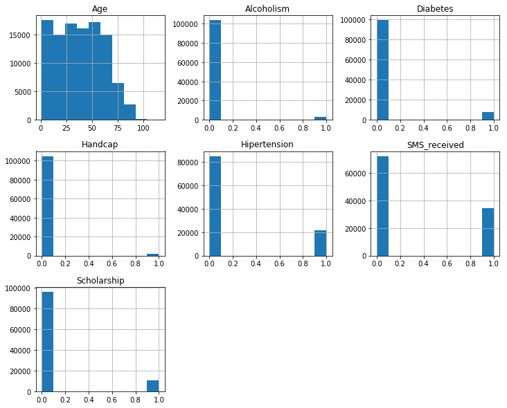

```python
# Use this, and more code cells, to explore your data. Don't forget to add
#   Markdown cells to document your observations and findings.
df.hist(figsize=(12,10));
```

Now let us check how each factor effects the absence of patients.

```python
df['No-show'].value_counts()
```

```
No     85149
Yes    21639
Name: No-show, dtype: int64
```

Since we will be drawing a histogram assoctiated with attendance multiple times, it is more sensible to use a function for that sole purpose.

```python
def printAttendanceHistogram(title,VariablePresent,VariableAbsent,varlabel):
    VariableAbsent.hist(alpha = 0.5,label='Did not Come',color='red')
    VariablePresent.hist(alpha = 0.5,label='Came',color='green')
    plt.xlabel(varlabel)
    plt.ylabel('# of Attended/Did Not Attend')
    plt.title(title)
    plt.legend();
```

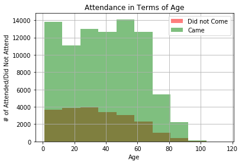

```python
printAttendanceHistogram('Attendance in Terms of Age',df.Age[present],df.Age[absent],'Age')
```

It seems that elderly men and children are more likly to attend compared to teens and men in their 30s, but there does not seem to be a huge correlation here.

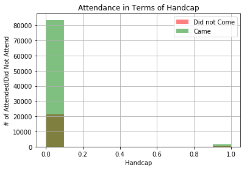

```python
printAttendanceHistogram('Attendance in Terms of Handcap',df.Handcap[present],df.Handcap[absent],'Handcap')
```

No real correlation between being handicapped and attendence.

```python
df.Handcap.value_counts()
```

```
0    104747
1      2041
Name: Handcap, dtype: int64
```

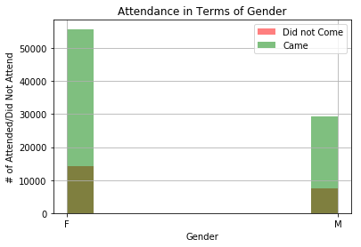

```python
printAttendanceHistogram('Attendance in Terms of Gender',df.Gender[present],df.Gender[absent],'Gender')
```

```python
df.Gender.value_counts()
```

```
F    70009
M    36779
Name: Gender, dtype: int64
```

No correlation between the type of gender and attendace, the spike in female attendes is due to their huge numbers compared to male attendes.

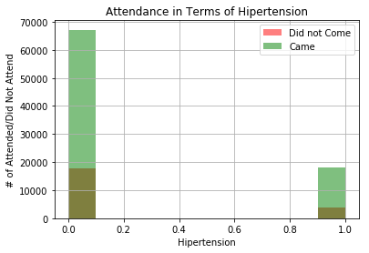

```python
printAttendanceHistogram('Attendance in Terms of Hipertension',df.Hipertension[present],df.Hipertension[absent],'Hipertension')
```

Again, no real correlation could be associated with hipertension, the people atteding have hipertension propotional to those who did not attend and had it.

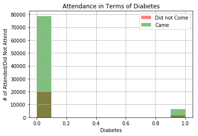

```python
printAttendanceHistogram('Attendance in Terms of Diabetes',df.Diabetes[present],df.Diabetes[absent],'Diabetes')
```

Again, no real correlation could be associated with diabetes, the people atteding have diabetes propotional to those who did not attend and had it.

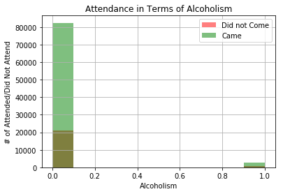

```python
printAttendanceHistogram('Attendance in Terms of Alcoholism',df.Alcoholism[present],df.Alcoholism[absent],'Alcoholism')
```

Again, no real correlation could be associated with alcoholism, the people atteding have alcoholism propotional to those who did not attend and had it.

In terms of neighbourhood, we can't show a graph with hospital names since there are way too many, so we will view the number of present and absent patients in each neighbourhood and look for accoring trends.

```python
df.Neighbourhood[present].value_counts()
```

```
JARDIM CAMBURI         6154
MARIA ORTIZ            4369
RESISTÊNCIA            3352
JARDIM DA PENHA        3219
CENTRO                 2588
SANTA MARTHA           2539
ITARARÉ                2509
TABUAZEIRO             2462
SANTO ANTÔNIO          2197
BONFIM                 2161
JESUS DE NAZARETH      2043
SANTO ANDRÉ            1967
JABOUR                 1964
CARATOÍRA              1903
SÃO PEDRO              1837
NOVA PALESTINA         1760
DA PENHA               1727
ILHA DO PRÍNCIPE       1696
ANDORINHAS             1680
ROMÃO                  1653
ILHA DE SANTA MARIA    1482
GURIGICA               1476
FORTE SÃO JOÃO         1475
BELA VISTA             1468
SÃO JOSÉ               1459
MARUÍPE                1445
SÃO CRISTÓVÃO          1424
REDENÇÃO               1233
JOANA D´ARC            1112
CONSOLAÇÃO             1103
                       ...
DO CABRAL               450
ESTRELINHA              428
SANTOS REIS             413
SOLON BORGES            385
SANTA CLARA             363
PIEDADE                 351
SANTA LÚCIA             349
SANTA LUÍZA             339
BARRO VERMELHO          327
SANTA CECÍLIA           323
MÁRIO CYPRESTE          314
DO MOSCOSO              304
COMDUSA                 253
DE LOURDES              252
BOA VISTA               247
ANTÔNIO HONÓRIO         212
FRADINHOS               208
ARIOVALDO FAVALESSA     207
ENSEADA DO SUÁ          177
SANTA HELENA            138
HORTO                   128
UNIVERSITÁRIO           119
SEGURANÇA DO LAR        114
NAZARETH                105
MORADA DE CAMBURI        79
PONTAL DE CAMBURI        57
ILHA DO BOI              32
ILHA DO FRADE             8
AEROPORTO                 7
PARQUE INDUSTRIAL         1
Name: Neighbourhood, Length: 80, dtype: int64
```

```python
df.Neighbourhood[absent].value_counts()
```

```
JARDIM CAMBURI                 1432
MARIA ORTIZ                    1194
ITARARÉ                         896
RESISTÊNCIA                     872
CENTRO                          690
JESUS DE NAZARETH               676
JARDIM DA PENHA                 627
CARATOÍRA                       585
TABUAZEIRO                      552
BONFIM                          536
ILHA DO PRÍNCIPE                519
ANDORINHAS                      508
SÃO PEDRO                       494
SANTA MARTHA                    484
SANTO ANDRÉ                     482
SANTO ANTÔNIO                   474
ROMÃO                           464
JABOUR                          432
GURIGICA                        429
DA PENHA                        421
MARUÍPE                         419
SÃO JOSÉ                        405
NOVA PALESTINA                  384
SANTOS DUMONT                   364
SÃO CRISTÓVÃO                   359
BELA VISTA                      358
ILHA DE SANTA MARIA             341
FORTE SÃO JOÃO                  334
CRUZAMENTO                      297
PRAIA DO SUÁ                    288
                               ...
SANTA CECÍLIA                   120
MATA DA PRAIA                   110
SANTOS REIS                     107
ESTRELINHA                      104
BARRO VERMELHO                   91
DO MOSCOSO                       89
SANTA LÚCIA                      84
DO CABRAL                        84
PIEDADE                          84
SANTA LUÍZA                      74
SOLON BORGES                     67
ARIOVALDO FAVALESSA              61
BOA VISTA                        58
COMDUSA                          55
MÁRIO CYPRESTE                   53
ENSEADA DO SUÁ                   51
FRADINHOS                        46
ANTÔNIO HONÓRIO                  45
DE LOURDES                       45
HORTO                            38
SANTA HELENA                     36
UNIVERSITÁRIO                    32
NAZARETH                         27
SEGURANÇA DO LAR                 26
MORADA DE CAMBURI                15
PONTAL DE CAMBURI                12
ILHA DO BOI                       3
ILHA DO FRADE                     2
ILHAS OCEÂNICAS DE TRINDADE       2
AEROPORTO                         1
Name: Neighbourhood, Length: 80, dtype: int64
```

The ratio of pateints attending compared to those who did not attend in each neighbourhood seems to be similar to each other.

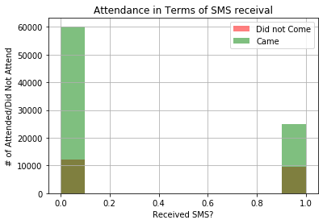

```python
printAttendanceHistogram('Attendance in Terms of SMS receival',df.SMS_received[present],df.SMS_received[absent],'Received SMS?')
```

It is interesting here because the patients who did not recive the sms were more likely to attend, so it seems that sms are not affective in drawing patients to attend.

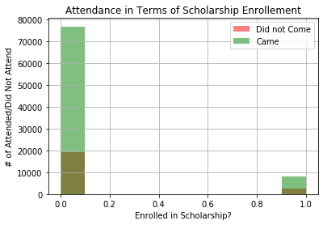

```python
printAttendanceHistogram('Attendance in Terms of Scholarship Enrollement',
                         df.Scholarship[present],df.Scholarship[absent],'Enrolled in Scholarship?')
```

Again, no real correlation could be associated with scholarship, the people atteding have scholarship registerers propotional to those who did not attend and had it.

It seems that the two variables we should keep an eye on are SMS messages and age, lets see if there is any interesting relation between these two.

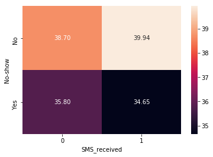

```python
#flights=df.pivot('No-show',"Age",  "SMS_received")
SMSAge=df.pivot_table(index='No-show', columns='SMS_received', values='Age', aggfunc='mean')
ax = sns.heatmap(SMSAge, annot=True, fmt=".2f")
```

Let's make sure that there are no important correlations that we missed between variables.

We will need to change attendace to 0/1 rather than Yes/No so it could be calculated with the correlation function.

(Remember that 'No' means the patient attended while 'Yes' means that they did not attend)

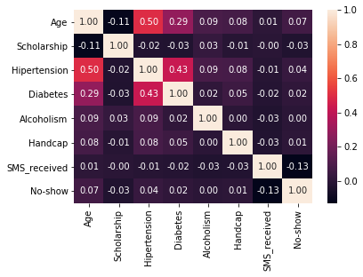

```python
df['No-show']=df['No-show'].map(dict(No=1, Yes=0))
sns.heatmap(df.corr(), annot=True, fmt=".2f")
plt.show()
```

As we expected before, age had a small correlation, while SMS had the opposite effect of drawing patients to attend the appointment.

There seems to be a correlation between having hipertension/diabetes and being at an eardley age, but that correlation is just normal.

## Conclusions

In general two conclusions can be made:

1-Children and elderly are a bit more likely to attend their appointments.

2-SMS messages seem to be not very effective in drawing patients to attend.

The limitations of this exploration is that we don't know how far patients where from their neighbourhood hospitals, maybe patients who live far from their neighbourhood hospitals are less likely to attend their appointments.

```python
from subprocess import call
call(['python', '-m', 'nbconvert', 'Investigate_a_Dataset.ipynb'])
```